# R Laboratory 5

```r
library(ggplot2)
library(latex2exp)
library(gridExtra)
library(grid)
```

## Exercise 1

• the number of particles emitted by a radioactive source during a fixed interval of time (∆t = 10 s) follows a Poisson distribution on the parameter μ. The number of particles observed during consecutive time intervals is: 4, 1, 3, 1 and 3

1. suppose a uniform prior distribution for the parameter μ
- determine and draw the posterior distribution for μ, given the data
- evaluate mean, median and variance, both analytically and numerically in R
2. suppose a Jeffrey’s prior for the parameter μ
- determine and draw the posterior distribution for μ, given the data
- evaluate mean, median and variance, both analytically and numerically in R
3. evaluate a 95% credibility interval for the results obtained with both priors. Compare the result with that obtained using a normal approximation for the posterior distribution, with the same mean and standard deviation

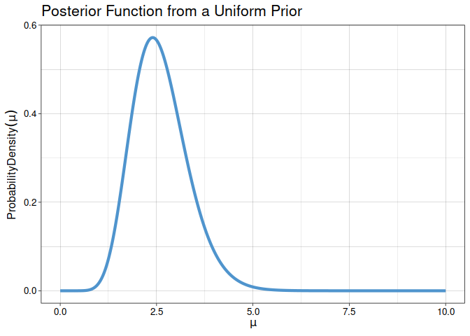

```r
obs <- c(4,1,3,1,3)
mu_range <- seq(0,10, by=0.01)

#from a uniform prior
posterior_u <- dgamma(mu_range, shape = sum(obs) + 1, rate=length(obs))

plot <- ggplot() + theme_linedraw() +
       geom_line(aes(x=mu_range, y=posterior_u), color='steelblue3', lwd=1.5) +
 ggtitle("Posterior Function from a Uniform Prior")+ labs(x=TeX('$\\mu$'),
                              y= TeX('$ProbabilityDensity(\\mu)$')) +
                theme(plot.title = element_text(size=16),
                  axis.text.x = element_text(size=10),
                  axis.text.y = element_text(size=10),
                  axis.title.x = element_text(size=12),
                  axis.title.y = element_text(size=12))

plot
```

```r
#Analytic mean and variance

mean_post_u <- ((sum(obs) + 1)/length(obs))   #alpha/beta
cat("\nThe analytic mean of the found Posterior distribution is:", mean_post_u)
```

```
The analytic mean of the found Posterior distribution is: 2.6
```

```r
var_post_u <- ((sum(obs) + 1)/(length(obs))^2)    #alpha/beta^2
cat("\nThe analytic variance of the found Posterior distribution is:", var_post_u)
```

```
The analytic variance of the found Posterior distribution is: 0.52
```

```r
#Numerical mean, median and variance

mean_int <- function(x){
  return (x*dgamma(x, shape = sum(obs) + 1, rate=length(obs)))
}

mean_num <- integrate(mean_int, lower = 0 , upper = Inf)
cat("\nThe numerical mean of the found Posterior distribution is:", mean_num$value)
```

```
The numerical mean of the found Posterior distribution is: 2.6
```

```r
cumul <- pgamma(mu_range, shape = sum(obs) + 1, rate=length(obs))
median_num <- mu_range[length(cumul[cumul < 0.5])]

cat("\nThe numeric median of the found Posterior distribution is:", median_num)
```

```
The numeric median of the found Posterior distribution is: 2.53
```

```r
var_int <- function(x){
  return ((x^2)*dgamma(x, shape = sum(obs) + 1, rate=length(obs)))
}

var_num <- integrate(var_int, lower = 0 , upper = Inf)
cat("\nThe numerical variance of the found Posterior distribution is:", var_num$value - mean_num$value^2)
```

```
The numerical variance of the found Posterior distribution is: 0.52
```

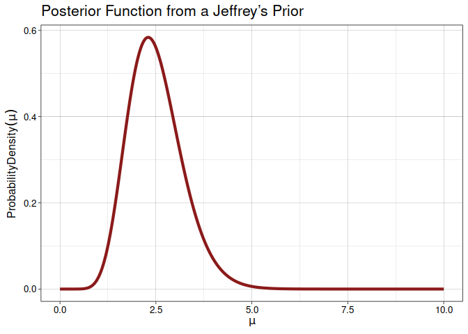

```r
#from a Jeffrey’s prior
posterior_j <- dgamma(mu_range, shape = sum(obs) + 1/2, rate=length(obs))

plot <- ggplot() + theme_linedraw() +
       geom_line(aes(x=mu_range, y=posterior_j), color='firebrick4', lwd=1.5) +
 ggtitle("Posterior Function from a Jeffrey’s Prior")+ labs(x=TeX('$\\mu$'),
                              y= TeX('$ProbabilityDensity(\\mu)$')) +
                theme(plot.title = element_text(size=16),
                  axis.text.x = element_text(size=10),
                  axis.text.y = element_text(size=10),
                  axis.title.x = element_text(size=12),
                  axis.title.y = element_text(size=12))

plot
```

```r
#Analytic mean and variance

mean_post_j <- ((sum(obs) + 1/2)/length(obs))   #alpha/beta
cat("\nThe analytic mean of the found Posterior distribution is:", mean_post_j)
```

```
The analytic mean of the found Posterior distribution is: 2.5
```

```r
var_post_j <- ((sum(obs) + 1/2)/(length(obs))^2)    #alpha/beta^2
cat("\nThe analytic variance of the found Posterior distribution is:", var_post_j)
```

```
The analytic variance of the found Posterior distribution is: 0.5
```

```r
#Numerical mean, median and variance

mean_int <- function(x){
  return (x*dgamma(x, shape = sum(obs) + 1/2, rate=length(obs)))
}

mean_num <- integrate(mean_int, lower = 0 , upper = Inf)
cat("\nThe numerical mean of the found Posterior distribution is:", mean_num$value)
```

```
The numerical mean of the found Posterior distribution is: 2.5
```

```r
cumul_j <- pgamma(mu_range, shape = sum(obs) + 1/2, rate=length(obs))
median_num <- mu_range[length(cumul_j[cumul_j < 0.5])]

cat("\nThe numeric median of the found Posterior distribution is:", median_num)
```

```
The numeric median of the found Posterior distribution is: 2.43
```

```r
var_int <- function(x){
  return ((x^2)*dgamma(x, shape = sum(obs) + 1/2, rate=length(obs)))
}

var_num <- integrate(var_int, lower = 0 , upper = Inf)
cat("\nThe numerical variance of the found Posterior distribution is:", var_num$value - mean_num$value^2)
```

```
The numerical variance of the found Posterior distribution is: 0.5
```

```r
cumul_unif <- pgamma(mu_range, shape = sum(obs) + 1, rate=length(obs))

unif_l_lim <- mu_range[length(cumul[cumul < 0.025])]
unif_h_lim <- mu_range[length(cumul[cumul < 0.975])]


cat("\n95 % Credibility Interval :
    \t", unif_l_lim, "-", unif_h_lim, "with the Uniform prior")
```

```
95 % Credibility Interval :
         1.38 - 4.19 with the Uniform prior
```

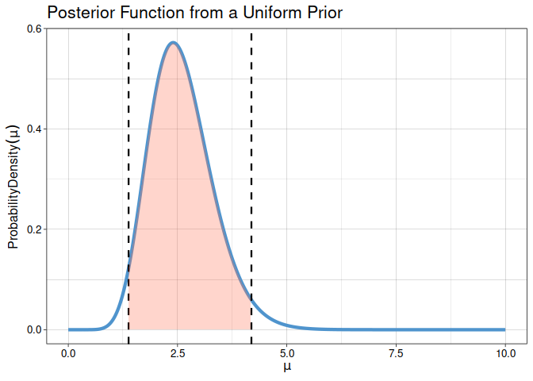

```r
x_plot <- seq(unif_l_lim, unif_h_lim, by=0.1)
cred_plot <- dgamma(x_plot, shape = sum(obs) + 1, rate=length(obs) )

plot <- ggplot() + theme_linedraw() +
       geom_line(aes(x=mu_range, y=posterior_u), color='steelblue3', lwd=1.5) +
        geom_vline(xintercept = unif_l_lim , linetype='dashed', lwd=0.8) +
        geom_vline(xintercept = unif_h_lim , linetype='dashed', lwd=0.8) +
        geom_ribbon(aes(x=x_plot, ymin=0 , ymax=cred_plot), alpha =0.3, fill = 'coral1') +

     ggtitle("Posterior Function from a Uniform Prior")+ labs(x=TeX('$\\mu$'),
                                         y= TeX('$ProbabilityDensity(\\mu)$')) +
                theme(plot.title = element_text(size=16),
                  axis.text.x = element_text(size=10),
                  axis.text.y = element_text(size=10),
                  axis.title.x = element_text(size=12),
                  axis.title.y = element_text(size=12))

plot
```

```r
#limit with another method
jef_l_lim <- round((qgamma(0.025, sum(obs) + 1/2, length(obs))),2)
jef_h_lim <- round((qgamma(0.975, sum(obs) + 1/2, length(obs))),2)


cat("\n95 % Credibility Interval :
\t", jef_l_lim, "-", jef_h_lim, "with the Jeffrey's prior")
```

```
95 % Credibility Interval :
     1.31 - 4.06 with the Jeffrey's prior
```

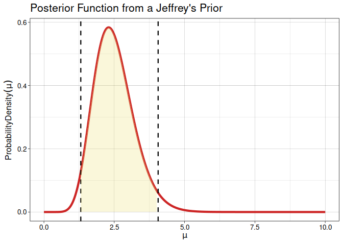

```r
x_plot <- seq(jef_l_lim, jef_h_lim, by=0.1)
cred_plot <- dgamma(x_plot, shape = sum(obs) + 1/2, rate=length(obs) )

plot <- ggplot() + theme_linedraw() +
       geom_line(aes(x=mu_range, y=posterior_j), color='firebrick3', lwd=1.5) +
        geom_vline(xintercept = jef_l_lim , linetype='dashed', lwd=0.8) +
        geom_vline(xintercept = jef_h_lim , linetype='dashed', lwd=0.8) +
   geom_ribbon(aes(x=x_plot, ymin=0 , ymax=cred_plot), alpha =0.3, fill = 'khaki2') +

     ggtitle("Posterior Function from a Jeffrey's Prior")+ labs(x=TeX('$\\mu$'),
                                         y= TeX('$ProbabilityDensity(\\mu)$')) +
                theme(plot.title = element_text(size=16),
                  axis.text.x = element_text(size=10),
                  axis.text.y = element_text(size=10),
                  axis.title.x = element_text(size=12),
                  axis.title.y = element_text(size=12))

plot
```

```r
posterior_n_u <- dnorm(mu_range, mean=mean_post_u, sd=var_post_u)

norm_u_l_lim <- round((qnorm(0.025, mean=mean_post_u, sd=var_post_u)),2)
norm_u_h_lim <- round((qnorm(0.975, mean=mean_post_u, sd=var_post_u)),2)


cat("\n95 % Credibility Interval :
    \t", norm_u_l_lim, "-", norm_u_h_lim, "with the Uniform prior")
```

```
95 % Credibility Interval :
         1.58 - 3.62 with the Uniform prior
```

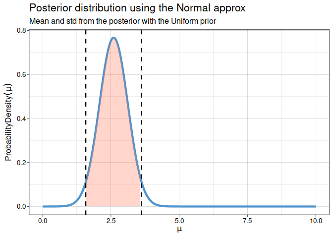

```r
x_plot <- seq(norm_u_l_lim, norm_u_h_lim, by=0.1)
cred_plot <- dnorm(x_plot, mean=mean_post_u, sd=var_post_u)

plot <- ggplot() + theme_linedraw() +
       geom_line(aes(x=mu_range, y=posterior_n_u), color='steelblue3', lwd=1.5) +
        geom_vline(xintercept = norm_u_l_lim , linetype='dashed', lwd=0.8) +
        geom_vline(xintercept = norm_u_h_lim , linetype='dashed', lwd=0.8) +
        geom_ribbon(aes(x=x_plot, ymin=0 , ymax=cred_plot), alpha =0.3, fill = 'coral1') +

     ggtitle("Posterior distribution using the Normal approx")+
              labs(x = TeX('$\\mu$'),y = TeX('$ProbabilityDensity(\\mu)$'), subtitle='Mean and std from the posterior with the Uniform prior') +
                theme(plot.title = element_text(size=16),
                      plot.subtitle = element_text(size=12),
                  axis.text.x = element_text(size=10),
                  axis.text.y = element_text(size=10),
                  axis.title.x = element_text(size=12),
                  axis.title.y = element_text(size=12))

plot
```

```r
NA
NA
```

```r
posterior_n_j <- dnorm(mu_range, mean=mean_post_j, sd=var_post_j)

norm_j_l_lim <- round((qnorm(0.025, mean=mean_post_j, sd=var_post_j)),2)
norm_j_h_lim <- round((qnorm(0.975, mean=mean_post_j, sd=var_post_j)),2)


cat("\n95 % Credibility Interval :
    \t", norm_j_l_lim, "-", norm_j_h_lim, "with the Jeffrey's prior")
```

```
95 % Credibility Interval :
         1.52 - 3.48 with the Jeffrey's prior
```

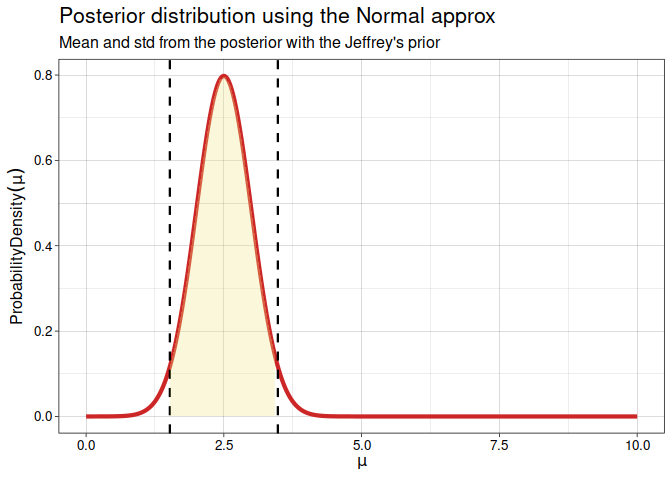

```r
x_plot <- seq(norm_j_l_lim, norm_j_h_lim, by=0.1)
cred_plot <- dnorm(x_plot, mean=mean_post_j, sd=var_post_j)

plot <- ggplot() + theme_linedraw() +
       geom_line(aes(x=mu_range, y=posterior_n_j), color='firebrick3', lwd=1.5) +
        geom_vline(xintercept = norm_j_l_lim , linetype='dashed', lwd=0.8) +
        geom_vline(xintercept = norm_j_h_lim , linetype='dashed', lwd=0.8) +
        geom_ribbon(aes(x=x_plot, ymin=0 , ymax=cred_plot), alpha =0.3, fill = 'khaki2') +

     ggtitle("Posterior distribution using the Normal approx")+
              labs(x = TeX('$\\mu$'),y = TeX('$ProbabilityDensity(\\mu)$'), subtitle="Mean and std from the posterior with the Jeffrey's prior") +
                theme(plot.title = element_text(size=16),
                      plot.subtitle = element_text(size=12),
                  axis.text.x = element_text(size=10),
                  axis.text.y = element_text(size=10),
                  axis.title.x = element_text(size=12),
                  axis.title.y = element_text(size=12))

plot
```

```r
df <- data.frame(row.names=c('Uniform Prior', "Jeffrey's Prior", 'Normal with Unif' , 'Normal with Jeffrey'))

df["LowerBound_CI_95%"] <- c(unif_l_lim, jef_l_lim, norm_u_l_lim, norm_j_l_lim)
df["UpperBound_CI_95%"] <- c(unif_h_lim, jef_h_lim, norm_u_h_lim, norm_j_h_lim)

df
```

|  | LowerBound_CI_95% | UpperBound_CI_95% |
| --- | --- | --- |
| Uniform Prior | 1.38 | 4.19 |
| Jeffrey's Prior | 1.31 | 4.06 |
| Normal with Unif | 1.58 | 3.62 |
| Normal with Jeffrey | 1.52 | 3.48 |

```r
NA
```

## Exercise 2

• given the problem of the lighthouse discussed last week, study the case in which both the position along the shore (α) and the distance out at sea (β) are unknown

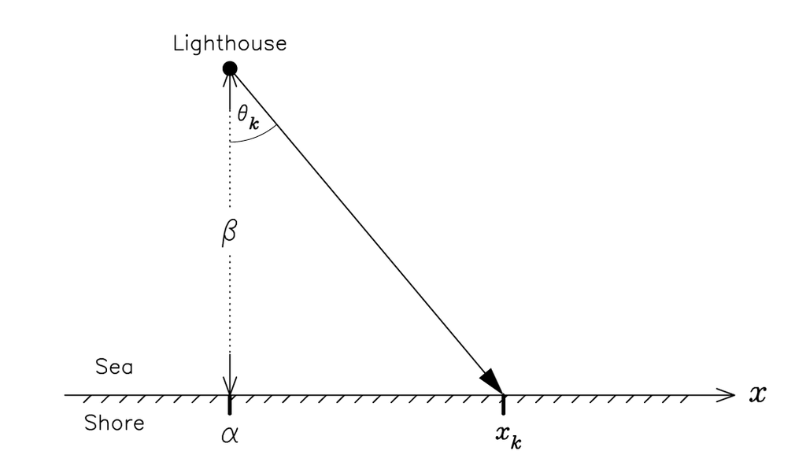

The Lighthouse Problem Setup

```r
n_sample <- 2000
alpha_tr <- 1
beta_tr <- 1

obs_theta <- runif(n_sample, -pi/2, pi/2)

obs_x <- beta_tr*tan(obs_theta) + alpha_tr   #our data


p_log_like <- function(a , b, data){
  logL <- 0.0
  for (x in data){
    logL <- logL + log( b/(b^2 + ((x-a)^2)))
  }
  return (logL)
}

a_min <- -7
a_max <- 7
h <- (a_max - a_min)/n_sample
alpha=seq(a_min, by=h , length.out = n_sample)


b_min <- 0
b_max <- 7
h2 <- (b_max - b_min)/n_sample
beta=seq(b_min, by= h2, length.out = n_sample)

repeat{
n_str <- readline (sprintf("Enter data set dimension (less or equal to %2.f): ", n_sample))
num <- as.numeric(n_str)
if (num > n_sample){cat("\n ERROR: The inserted number exceedes the number of samples:  ")}
else{ break}
}
153

dt <- obs_x[1:num]     #how much sample

z <- matrix(data = NA , nrow = length(alpha) , ncol = length(beta) )

for(j in 1:length(alpha)) {
    for(k in 1:length(beta)) {
      z[j,k] <- p_log_like(alpha[j], beta[k], dt)
     }
}

z <- z - max(z)

df <- data.frame(z)

#evaluate the posteriors for alpha and beta marginalizing
un_post_a <- apply(exp(df), 1, sum)
un_post_b <- apply(exp(df), 2, sum)
```

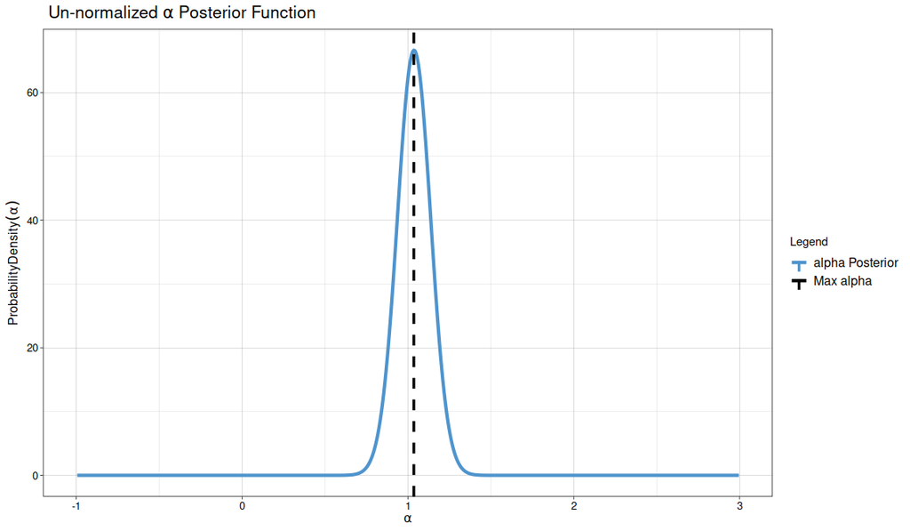

```r
index_max_a <- which.max(un_post_a)

plot <- ggplot() + theme_linedraw() +
  geom_line(aes(x=alpha, y=un_post_a , color='alpha Posterior'), lwd=1.5) +
  geom_vline( aes(xintercept = alpha[index_max_a], color = 'Max alpha') , linetype='dashed', lwd=1.2)+
    ggtitle(TeX(" Un-normalized $\\alpha$ Posterior Function"))+ labs(x=TeX('$\\alpha$'), y= TeX('$ProbabilityDensity(\\alpha)$'), color='Legend') +                                                                theme(legend.text=element_text(size=12))+
                  theme(plot.title = element_text(size=16),
                      axis.text.x = element_text(size=10),
                      axis.text.y = element_text(size=10),
                      axis.title.x = element_text(size=12),
                      axis.title.y = element_text(size=12)) +
   scale_color_manual(values = c( 'alpha Posterior' = 'steelblue3', 'Max alpha'='black')) + xlim(-1,3)

plot
```

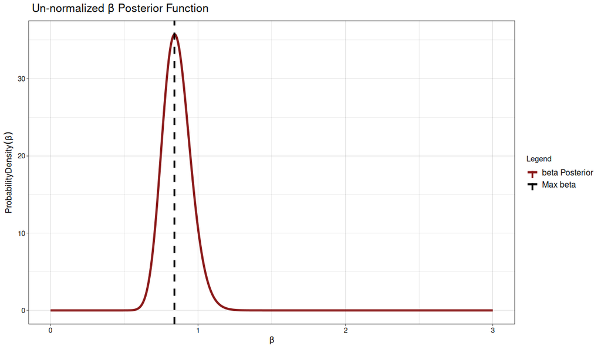

```r
index_max_b <- which.max(un_post_b)

plot <- ggplot() + theme_linedraw() +
  geom_line(aes(x=beta, y=un_post_b, color='beta Posterior'), lwd=1.5) +
  geom_vline( aes(xintercept = beta[index_max_b], color = 'Max beta') , linetype='dashed', lwd=1.2)+           ggtitle(TeX(" Un-normalized $\\beta$ Posterior Function"))+
            labs(x=TeX('$\\beta'), y= TeX('$ProbabilityDensity(\\beta)$'), color='Legend') +                                     theme(legend.text=element_text(size=12))+
                          theme(plot.title = element_text(size=16),
                          axis.text.x = element_text(size=10),
                          axis.text.y = element_text(size=10),
                          axis.title.x = element_text(size=12),
                          axis.title.y = element_text(size=12)) +
     scale_color_manual(values = c( 'beta Posterior' = 'firebrick4', 'Max beta'='black')) + xlim(0,3)

plot
```

```r
cat('alpha max: ', alpha[index_max_a] , '\n')
```

```
alpha max:  1.036
```

```r
cat('beta max: ', beta[index_max_b] , '\n')
```

```
beta max:  0.84
```

```r
posterior_alpha <- un_post_a/(h*sum(un_post_a))

cumul <- cumsum(posterior_alpha*((a_max-a_min)/n_sample))
l_lim <- alpha[length(cumul[cumul < 0.025])]
h_lim <- alpha[length(cumul[cumul < 0.975])]

y_ribbon <- posterior_alpha[length(cumul[cumul < 0.025]):length(cumul[cumul < 0.975])]

cat("\n95 % Credibility Interval :
    \t", l_lim, "-", h_lim)
```

```
95 % Credibility Interval :
         0.833 - 1.225
```

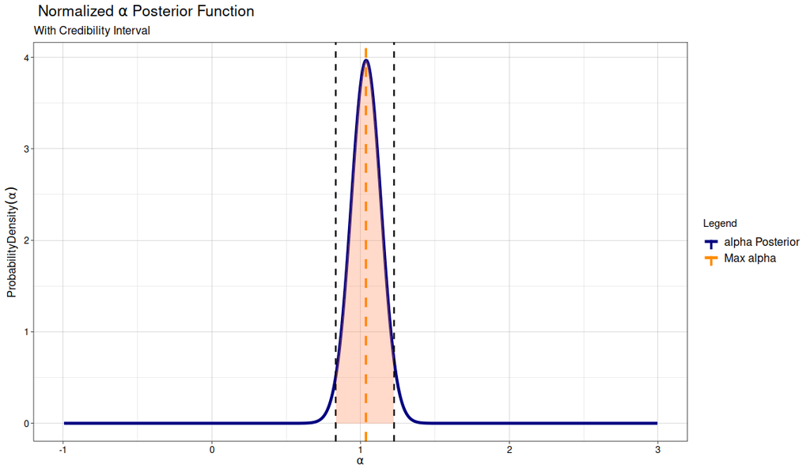

```r
x_plot_a <- seq(l_lim, h_lim, length.out=length(y_ribbon))

index_max_a <- which.max(posterior_alpha)


plot <- ggplot() + theme_linedraw() +
       geom_line(aes(x=alpha, y=posterior_alpha , color='alpha Posterior'), lwd=1.5) +
       geom_vline( aes(xintercept = alpha[index_max_a], color = 'Max alpha') , linetype='dashed', lwd=1.2)+ geom_vline(xintercept = l_lim , linetype='dashed', lwd=0.8) +
        geom_vline(xintercept = h_lim , linetype='dashed', lwd=0.8) +
        geom_ribbon(aes(x=x_plot_a, ymin=0 , ymax=y_ribbon), alpha =0.3, fill ='coral') +
 ggtitle(TeX(" Normalized $\\alpha$ Posterior Function"))+ labs(x=TeX('$\\alpha$'), y= TeX('$ProbabilityDensity(\\alpha)$'), subtitle="With Credibility Interval", color='Legend' )+                      theme(legend.text=element_text(size=12))+  theme(plot.title = element_text(size=16),
                   plot.subtitle = element_text(size=12),
                  axis.text.x = element_text(size=10),
                  axis.text.y = element_text(size=10),
                  axis.title.x = element_text(size=12),
                  axis.title.y = element_text(size=12)) +
  scale_color_manual(values = c( 'alpha Posterior' = 'navy', 'Max alpha'='darkorange')) + xlim(-1,3)


plot
```

```r
posterior_beta <- un_post_b/(h2*sum(un_post_b))

cumul <- cumsum(posterior_beta*((b_max-b_min)/n_sample))
l_lim <- beta[length(cumul[cumul < 0.025])]
h_lim <- beta[length(cumul[cumul < 0.975])]

y_ribbon <- posterior_beta[length(cumul[cumul < 0.025]):length(cumul[cumul < 0.975])]

cat("\n95 % Credibility Interval :
    \t", l_lim, "-", h_lim)
```

```
95 % Credibility Interval :
         0.6825 - 1.057
```

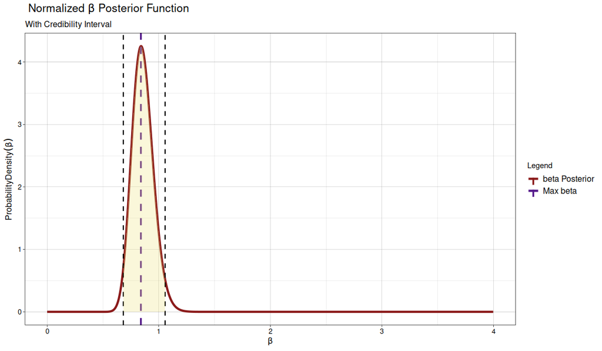

```r
x_plot_b <- seq(l_lim, h_lim, length.out=length(y_ribbon))

index_max_b <- which.max(posterior_beta)


plot <- ggplot() + theme_linedraw() +
       geom_line(aes(x=beta, y=posterior_beta , color='beta Posterior'), lwd=1.5) +
       geom_vline( aes(xintercept = beta[index_max_b], color = 'Max beta') , linetype='dashed', lwd=1.2)+  geom_vline(xintercept = l_lim , linetype='dashed', lwd=0.8) +
        geom_vline(xintercept = h_lim , linetype='dashed', lwd=0.8) +
        geom_ribbon(aes(x=x_plot_b, ymin=0 , ymax=y_ribbon), alpha =0.3, fill ='khaki2') +
 ggtitle(TeX(" Normalized $\\beta$ Posterior Function"))+ labs(x=TeX('$\\beta$'), y= TeX('$ProbabilityDensity(\\beta)$'), subtitle="With Credibility Interval", color='Legend') +                                 theme(legend.text=element_text(size=12))+
                    theme(plot.title = element_text(size=16),
                   plot.subtitle = element_text(size=12),
                  axis.text.x = element_text(size=10),
                  axis.text.y = element_text(size=10),
                  axis.title.x = element_text(size=12),
                  axis.title.y = element_text(size=12)) +
  scale_color_manual(values = c( 'beta Posterior' = 'firebrick4', 'Max beta'='purple4')) +xlim(0,4)


plot
```

```r
NA
NA
```

## Exercise 3

• given the Signal over Background example discussed last week, analyze and discuss the following cases:

1. vary the sampling resolution of used to generate the data, keeping the sample range

xdat <- seq(from=-7*w, to=7*w, by=0.5*w)

• change the resolution
$$\omega = \{ 0.1, 0.25, 1, 2, 3 \}$$
• check the effect on the results

2. change the ratio A/B used to simulate the data (keeping both positive in accordance with the prior)

• check the effect on the results

```r
# - Generative model
signal <- function(x, a, b, x0, w, t) {
         t * (a*exp(-(x-x0)^2/(2*w^2)) + b)
}


# Define model parameters
x0 <- 0     #signal peak
w <-1       #signal width
A_true <- 2    #signal amplitude
B_true <- 1   #background amplitude
Delta_t <- 5  #exposure time


set.seed(777)
xdat <- seq(from=-7*w, to=7*w, by=0.5*w)
s_true <- signal(xdat, A_true, B_true, x0, w, Delta_t)
ddat <- rpois(length(s_true), s_true)

xdat_off = xdat-0.25
xplot <- seq(from=min(xdat), to=max(xdat), by=0.05*w)
splot <- signal(xplot, A_true, B_true, x0, w, Delta_t)


plot <- ggplot() + theme_linedraw() + scale_x_continuous(breaks = -10:10 , labels = -10:10)+
    geom_point(aes(x=xplot, y=splot), size=2.7, fill='steelblue1', color='black', pch=21) +
    geom_step(aes(x= xdat_off, y=ddat), direction = 'vh', lwd=1.5, color='firebrick', alpha=0.7) +
 ggtitle("Signal with Background")+ labs(x='x', y='Signal + background Counts') +
                theme(plot.title = element_text(size=20),
                  axis.text.x = element_text(size=15),
                  axis.text.y = element_text(size=15),
                  axis.title.x = element_text(size=16),
                  axis.title.y = element_text(size=16))

plot
```

[output not shown]

```r
# - Sampling grid for computing posterior
alim <- c(0.0, 4.0)
blim <- c(0.5, 1.5)
Nsamp <- 100
uniGrid <- seq(from=1/(2*Nsamp), to=1-1/(2*Nsamp), by=1/Nsamp)
delta_a <- diff(alim)/Nsamp
delta_b <- diff(blim)/Nsamp
a <- alim[1] + diff(alim)*uniGrid
b <- blim[1] + diff(blim)*uniGrid

# Log posterior
log.post <- function(d, x, a, b, x0, w, t) {
            if(a<0 || b <0) {
                return(-Inf)
            } # the effect of the prior
        sum(dpois(d, lambda=signal(x, a, b, x0, w, t), log=TRUE))
}


z <- matrix(data=NA, nrow=length(a), ncol=length(b))
for(j in 1:length(a)) {
    for(k in 1:length(b)) {
        z[j,k] <- log.post(ddat, xdat, a[j], b[k], x0, w, Delta_t)
    }
}
z <- z - max(z) # set maximum to zero



# Plot un-normalized 2D posterior as contours
plot_contour <- contour(a, b, exp(z), nlevels = 5, labcex = 1, lwd = 2,
                  xlab="Amplitude A", ylab="Background",
                  main='Un-normalized Posterior Contour Plot', col='springgreen4')
                  abline(v=A_true, h=B_true, col="darkorange3")
```

[output not shown]

```r
p_a_D <- apply(exp(z), 1, sum)
p_a_D <- p_a_D/(delta_a*sum(p_a_D))
p_b_D <- apply(exp(z), 2, sum)
p_b_D <- p_b_D/(delta_b*sum(p_b_D))

p_a_bD <- exp(Vectorize(log.post, "a")(ddat, xdat, a, B_true,x0, w, Delta_t))
p_a_bD <- p_a_bD/(delta_a*sum(p_a_bD))
p_b_aD <- exp(Vectorize(log.post, "b")(ddat, xdat, A_true, b,x0, w, Delta_t))
p_b_aD <- p_b_aD/(delta_b*sum(p_b_aD))



#computation of the credibility intervals
cumul <- cumsum(p_a_D*((max(a)-min(a))/length(a)))

l_bound <- a[length(cumul[cumul < 0.025])]
u_bound <- a[length(cumul[cumul < 0.975])]
y_ribbon <- p_a_D[length(cumul[cumul < 0.025]):length(cumul[cumul < 0.975])]
x_plot_a <- seq(l_bound, u_bound, length.out=length(y_ribbon))

plot_a <- ggplot() +  theme_linedraw() +
    geom_line(aes(x = a,y =  p_a_D, color='P(a|D)'), lwd=1.5) +
    geom_line(aes(x = a,y =  p_a_bD, color='P(a|b,D)'), linetype='dashed', lwd=1.5) +
    labs(title=TeX('Plot of $P(a|D)$ and $P(a|b,D)$'), x='a', y='Probability density', color='Legend', subtitle="With Credibility Interval") +
    geom_ribbon(aes(x = x_plot_a, ymin=0, ymax=y_ribbon), fill='slategray2', alpha=0.4) +
    geom_vline(aes(xintercept=l_bound),  color='black', linetype='dashed', lwd=1.2) +
    geom_vline(aes(xintercept=u_bound), linetype='dashed', lwd=1.2, color='black') +
    scale_color_manual(values = c('P(a|D)'='purple3', 'P(a|b,D)'='green')) +
             theme(plot.title = element_text(size=20),
                  plot.subtitle = element_text(size=15),
                  axis.text.x = element_text(size=15),
                  axis.text.y = element_text(size=15),
                  axis.title.x = element_text(size=16),
                  axis.title.y = element_text(size=16),
                  legend.text = element_text(size=15),
                  legend.title = element_text(size=15))


plot_a
```

[output not shown]

```r
#computation of the credibility intervals
cumul <- cumsum(p_b_D*((max(b)-min(b))/length(b)))

l_bound <- b[length(cumul[cumul < 0.025])]
u_bound <- b[length(cumul[cumul < 0.975])]
y_ribbon <- p_b_D[length(cumul[cumul < 0.025]):length(cumul[cumul < 0.975])]
x_plot_b <- seq(l_bound, u_bound, length.out=length(y_ribbon))

plot_b <- ggplot() +  theme_linedraw() +
    geom_line(aes(x = b,y =  p_b_D, color='P(b|D)'), lwd=1.5) +
    geom_line(aes(x = b,y =  p_b_aD, color='P(b|a,D)'), linetype='dashed', lwd=1.5) +
    labs(title=TeX('Plot of $P(b|D)$ and $P(b|a,D)$'), x='b', y='Probability density', color='Legend', subtitle="With Credibility Interval") +
    geom_ribbon(aes(x = x_plot_b, ymin=0, ymax=y_ribbon), fill='thistle2', alpha=0.4) +
    geom_vline(aes(xintercept=l_bound),  color='black', linetype='dashed', lwd=1.2) +
    geom_vline(aes(xintercept=u_bound), linetype='dashed', lwd=1.2, color='black') +
    scale_color_manual(values = c('P(b|D)'='navy', 'P(b|a,D)'='darkorange')) +
             theme(plot.title = element_text(size=20),
                  plot.subtitle = element_text(size=15),
                  axis.text.x = element_text(size=15),
                  axis.text.y = element_text(size=15),
                  axis.title.x = element_text(size=16),
                  axis.title.y = element_text(size=16),
                  legend.text = element_text(size=15),
                  legend.title = element_text(size=15))


plot_b
```

[output not shown]

```r
# Compute mean , standard deviation , covariance , correlation , of A and B
mean_a <- delta_a * sum(a * p_a_D)
mean_b <- delta_b * sum(b * p_b_D)
sd_a <- sqrt( delta_a * sum((a-mean_a)^2 * p_a_D) )
sd_b <- sqrt( delta_b * sum((b-mean_b)^2 * p_b_D) )


# Covariance normalization
# The normalization constant is Z = delta_a*delta_b*sum(exp(z)).
# This is independent of (a,b) so can be calculated outside of the loops.
cov_ab <- 0
for(j in 1:length(a)) {
    for(k in 1:length(b)) {
        cov_ab <- cov_ab + (a[j]-mean_a)*(b[k]-mean_b)*exp(z[j,k])
    }
}

cov_ab <- cov_ab / sum(exp(z))
rho_ab <- cov_ab / (sd_a * sd_b)
cat("a = ", mean_a, "±", sd_a, "\n")
cat("b = ", mean_b, "±", sd_b, "\n")
cat("rho = ", rho_ab, "\n")
```

[output not shown]

```r
signal_backround <- function(a_, b_, x0_, w_, t_){


    # - Generative model
    signal <- function(x, a, b, x0, w, t) {
            t * (a*exp(-(x-x0)^2/(2*w^2)) + b)
    }

# Define model parameters
x0 <- x0_     #signal peak
w <- w_       #signal width
A_true <- a_    #signal amplitude
B_true <- b_  #background amplitude
Delta_t <- t_  #exposure time


set.seed(777)
xdat <- seq(from = -7*w, to = 7*w, by = 0.5*w)
s_true <- signal(xdat, A_true, B_true, x0, w, Delta_t)
ddat <- rpois(length(s_true), s_true)

xdat_off = xdat - 0.25
xplot <- seq(from=min(xdat), to=max(xdat), by=0.05*w)
splot <- signal(xplot, A_true, B_true, x0, w, Delta_t)

plot <- ggplot() + theme_linedraw() + scale_x_continuous(breaks = -10:10 , labels = -10:10)+
    geom_point(aes(x=xplot, y=splot), size=3.5, fill='steelblue1', color='black', pch=21) +
    geom_step(aes(x= xdat_off, y=ddat), direction = 'vh', lwd=1.5, color='firebrick', alpha=0.7) +
 ggtitle("Signal with Background")+ labs(x='x', y='Signal + background Counts') +
                theme(plot.title = element_text(size=20),
                  axis.text.x = element_text(size=15),
                  axis.text.y = element_text(size=15),
                  axis.title.x = element_text(size=16),
                  axis.title.y = element_text(size=16))

# - Sampling grid for computing posterior
alim <- c(0.0, 4.0)
blim <- c(0.5, 1.5)
Nsamp <- 100
uniGrid <- seq(from=1/(2*Nsamp), to=1-1/(2*Nsamp), by=1/Nsamp)
delta_a <- diff(alim)/Nsamp
delta_b <- diff(blim)/Nsamp
a <- alim[1] + diff(alim)*uniGrid
b <- blim[1] + diff(blim)*uniGrid

# Log posterior
log.post <- function(d, x, a, b, x0, w, t) {
            if(a<0 || b <0) {
                return(-Inf)
            } # the effect of the prior
        sum(dpois(d, lambda=signal(x, a, b, x0, w, t), log=TRUE))
}


z <- matrix(data=NA, nrow=length(a), ncol=length(b))
for(j in 1:length(a)) {
    for(k in 1:length(b)) {
        z[j,k] <- log.post(ddat, xdat, a[j], b[k], x0, w, Delta_t)
    }
}
z <- z - max(z) # set maximum to zero

 p_a_D <- apply(exp(z), 1, sum)
 p_a_D <- p_a_D/(delta_a*sum(p_a_D))
 p_b_D <- apply(exp(z), 2, sum)
 p_b_D <- p_b_D/(delta_b*sum(p_b_D))


 p_a_bD <- exp(Vectorize(log.post, "a")(ddat, xdat, a, B_true,x0, w, Delta_t))
 p_a_bD <- p_a_bD/(delta_a*sum(p_a_bD))
 p_b_aD <- exp(Vectorize(log.post, "b")(ddat, xdat, A_true, b,x0, w, Delta_t))
 p_b_aD <- p_b_aD/(delta_b*sum(p_b_aD))


 #computation of the credibility intervals
cumul_a <- cumsum(p_a_D*((max(a)-min(a))/length(a)))

l_bound_a <- a[length(cumul_a[cumul_a < 0.025])]
u_bound_a <- a[length(cumul_a[cumul_a < 0.975])]
y_ribbon_a <- p_a_D[length(cumul_a[cumul_a < 0.025]):length(cumul_a[cumul_a < 0.975])]
x_plot_a <- seq(l_bound_a, u_bound_a, length.out=length(y_ribbon_a))

plot_a <- ggplot() +  theme_linedraw() +
    geom_line(aes(x = a,y =  p_a_D), color='purple3', lwd=1.5) +
    geom_line(aes(x = a,y =  p_a_bD), color='green', linetype='dashed', lwd=1.5) +
    labs(title='Plot of P(a|D) and P(a|b,D)', x='a', y='Probability density', subtitle=sprintf('w = %.2f, a/b = %.3s', w, a_/b_)) +
    geom_ribbon(aes(x = x_plot_a, ymin=0, ymax=y_ribbon_a), fill='slategray2', alpha=0.4) +
    geom_vline(aes(xintercept=l_bound_a),  color='black', linetype='dashed', lwd=1.2) +
    geom_vline(aes(xintercept=u_bound_a), linetype='dashed', lwd=1.2, color='black') +
             theme(plot.title = element_text(size=20),
                  plot.subtitle = element_text(size=15),
                  axis.text.x = element_text(size=15),
                  axis.text.y = element_text(size=15),
                  axis.title.x = element_text(size=16),
                  axis.title.y = element_text(size=16))

 #computation of the credibility intervals
cumul_b <- cumsum(p_b_D*((max(b)-min(b))/length(b)))

l_bound_b <- b[length(cumul_b[cumul_b < 0.025])]
u_bound_b <- b[length(cumul_b[cumul_b < 0.975])]
y_ribbon_b <- p_b_D[length(cumul_b[cumul_b < 0.025]):length(cumul_b[cumul_b < 0.975])]
x_plot_b <- seq(l_bound_b, u_bound_b, length.out=length(y_ribbon_b))

plot_b <- ggplot() +  theme_linedraw() +
    geom_line(aes(x = b,y =  p_b_D), color='navy', lwd=1.5) +
    geom_line(aes(x = b,y =  p_b_aD), color='darkorange', linetype='dashed', lwd=1.5) +
    labs(title='Plot of P(b|D) and P(b|a,D)', x='b', y='Probability density', subtitle= sprintf('w = %.2f, a/b = %.3s', w, a_/b_)) +
    geom_ribbon(aes(x = x_plot_b, ymin=0, ymax=y_ribbon_b), fill='thistle2', alpha=0.4) +
    geom_vline(aes(xintercept=l_bound_b),  color='black', linetype='dashed', lwd=1.2) +
    geom_vline(aes(xintercept=u_bound_b), linetype='dashed', lwd=1.2, color='black') +
             theme(plot.title = element_text(size=20),
                  plot.subtitle = element_text(size=15),
                  axis.text.x = element_text(size=15),
                  axis.text.y = element_text(size=15),
                  axis.title.x = element_text(size=16),
                  axis.title.y = element_text(size=16))

# Compute mean , standard deviation , covariance , correlation , of A and B
mean_a <- delta_a * sum(a * p_a_D)
mean_b <- delta_b * sum(b * p_b_D)
sd_a <- sqrt( delta_a * sum((a-mean_a)^2 * p_a_D) )
sd_b <- sqrt( delta_b * sum((b-mean_b)^2 * p_b_D) )


# Covariance normalization
# The normalization constant is Z = delta_a*delta_b*sum(exp(z)).
# This is independent of (a,b) so can be calculated outside of the loops.
cov_ab <- 0
for(j in 1:length(a)) {
    for(k in 1:length(b)) {
        cov_ab <- cov_ab + (a[j]-mean_a)*(b[k]-mean_b)*exp(z[j,k])
    }
}

cov_ab <- cov_ab / sum(exp(z))
rho_ab <- cov_ab / (sd_a * sd_b)


return(list(plot, plot_a, plot_b, c(mean_a, sd_a), c(mean_b, sd_b), rho_ab))

}
```

Check results changing the resolution
$$\omega = \{ 0.1, 0.25, 1, 2, 3 \}$$
maintaining the ratio a/b constant = 2.

```r
#function signal_background(a, b, x0, w, t)

results_01 = signal_backround(2, 1, 0, 0.1, 5)
results_025 = signal_backround(2, 1, 0, 0.25, 5)
results_1 = signal_backround(2, 1, 0, 1, 5)
results_2 = signal_backround(2, 1, 0, 2, 5)
results_3 = signal_backround(2, 1, 0, 3, 5)

grid.arrange(results_01[[2]], results_025[[2]],results_1[[2]], results_2[[2]], results_3[[2]], nrow=2)

grid.arrange(results_01[[3]], results_025[[3]],results_1[[3]], results_2[[3]], results_3[[3]], nrow=2)
```

[output not shown]

```r
ret <- list(results_01, results_025, results_1, results_2, results_3)
w <- c(0.1, 0.25, 1, 2, 3)
a_b <- rep(2, 5)

for (i in 1:5){
    cat(sprintf("w = %.2f and a_true/b_true = %.2s --> a = ", w[i], a_b[i]), ret[[i]][[4]][1], "±", ret[[i]][[4]][2], "\n")
    cat(sprintf("w = %.2f and a_true/b_true = %.2s --> b = ", w[i], a_b[i]), ret[[i]][[5]][1], "±", ret[[i]][[5]][2], "\n")
    cat(sprintf("w = %.2f and a_true/b_true = %.2s --> ρ = ", w[i], a_b[i]), ret[[i]][[6]], "\n\n")
}
```

[output not shown]

Now I analyze changing the ratio a/b but maintaining the resolution ω = 1 constant.

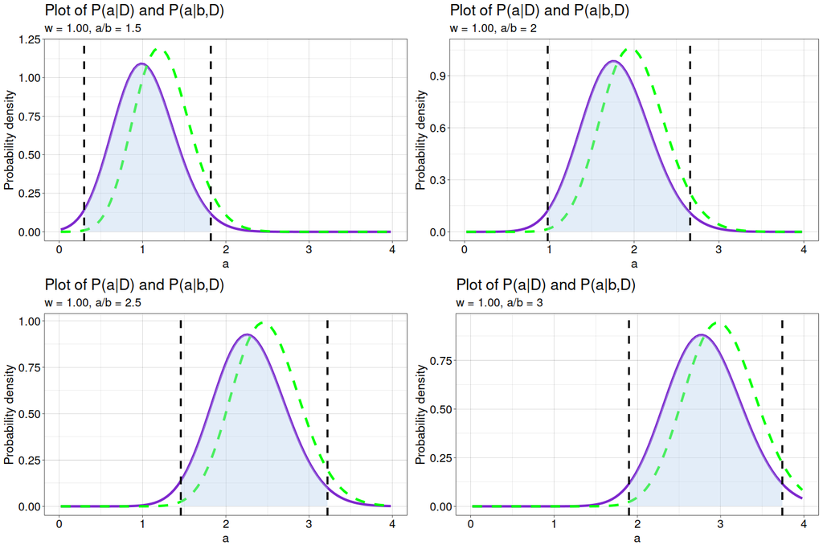

```r
#function signal_background(a, b, x0, w, t)

results_1.5 = signal_backround(1.5, 1, 0, 1, 5)
results_2 = signal_backround(2, 1, 0, 1, 5)
results_2.5 = signal_backround(2.5, 1, 0, 1, 5)
results_3 = signal_backround(3, 1, 0, 1, 5)

grid.arrange(results_1.5[[2]], results_2[[2]],results_2.5[[2]], results_3[[2]], nrow=2)
```

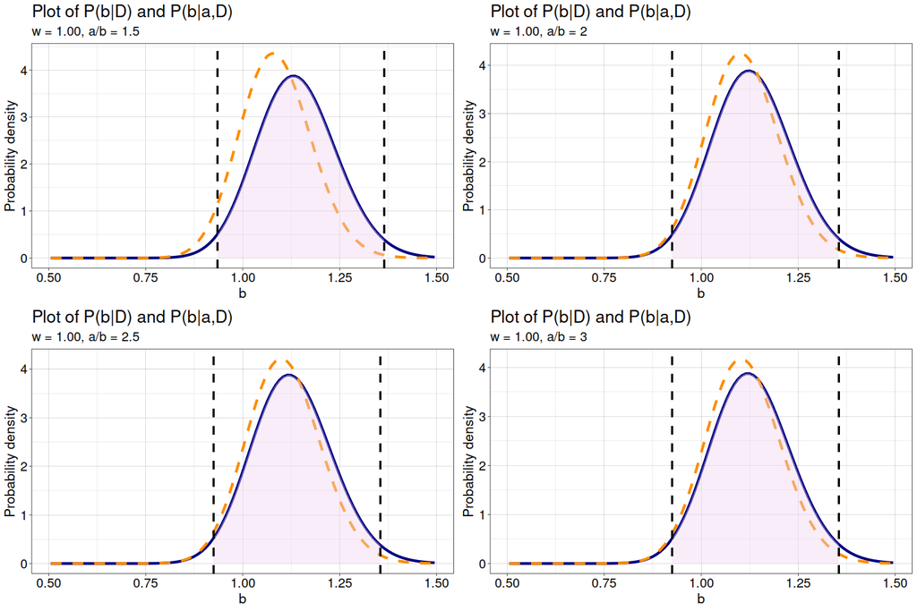

```r
grid.arrange(results_1.5[[3]], results_2[[3]],results_2.5[[3]], results_3[[3]], nrow=2)
```

```r
ret <- list(results_1.5, results_2, results_2.5, results_3)
w <- rep(1, 4)
a_b <- c(1.5, 2, 2.5, 3)

for (i in 1:4){
    cat(sprintf("w = %.2f and a_true/b_true = %.2s --> a = ", w[i], a_b[i]), ret[[i]][[4]][1], "±", ret[[i]][[4]][2], "\n")
    cat(sprintf("w = %.2f and a_true/b_true = %.2s --> b = ", w[i], a_b[i]), ret[[i]][[5]][1], "±", ret[[i]][[5]][2], "\n")
    cat(sprintf("w = %.2f and a_true/b_true = %.2s --> ρ = ", w[i], a_b[i]), ret[[i]][[6]], "\n\n")
}
```

```
w = 1.00 and a_true/b_true = 1. --> a =  1.028593 ± 0.3664173
w = 1.00 and a_true/b_true = 1. --> b =  1.139247 ± 0.1027729
w = 1.00 and a_true/b_true = 1. --> ρ =  -0.4255725

w = 1.00 and a_true/b_true = 2 --> a =  1.793424 ± 0.4065141
w = 1.00 and a_true/b_true = 2 --> b =  1.1312 ± 0.1026318
w = 1.00 and a_true/b_true = 2 --> ρ =  -0.3863475

w = 1.00 and a_true/b_true = 2. --> a =  2.292063 ± 0.4320038
w = 1.00 and a_true/b_true = 2. --> b =  1.127737 ± 0.1028155
w = 1.00 and a_true/b_true = 2. --> ρ =  -0.3699956

w = 1.00 and a_true/b_true = 3 --> a =  2.79703 ± 0.4449729
w = 1.00 and a_true/b_true = 3 --> b =  1.129111 ± 0.1029262
w = 1.00 and a_true/b_true = 3 --> ρ =  -0.3510116
```